# Phase 2 — Overlay Backtest Report

## Wealth comparison grid

10% overlay, all three trigger types vs 60/40 Classic.

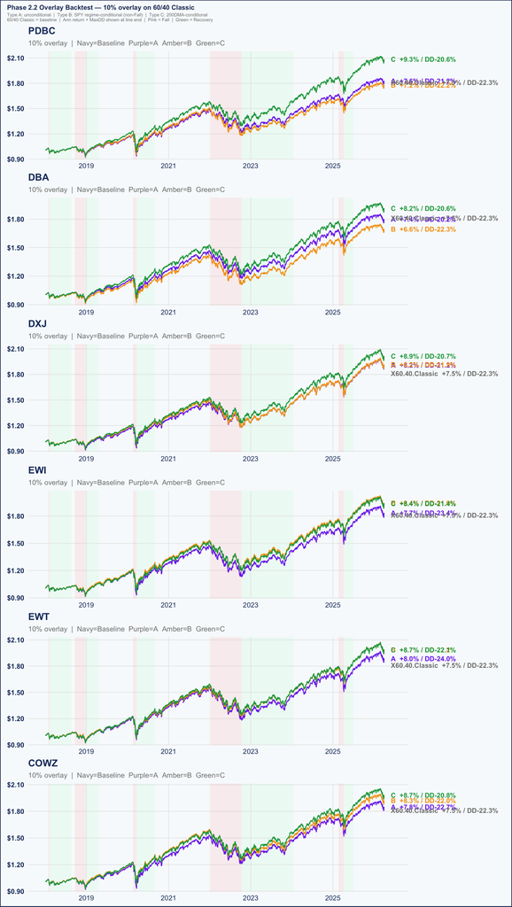

```r
# ob$p_grid
print(ob$p_grid)
```

## Full statistics table

| Ticker | Type | Ann Ret | MaxDD | Ann Vol | IR |
| --- | --- | --- | --- | --- | --- |
| COWZ | A | +7.8% | -22.7% | 12.3% | 0.67 |
| COWZ | B | +8.3% | -22.0% | 12.0% | 0.72 |
| COWZ | C | +8.7% | -20.8% | 11.8% | 0.76 |
| COWZ | X60.40.Classic | +7.5% | -22.3% | 11.6% | 0.68 |
| DBA | A | +7.4% | -20.2% | 10.8% | 0.71 |
| DBA | B | +6.6% | -22.3% | 11.2% | 0.63 |
| DBA | C | +8.2% | -20.6% | 11.2% | 0.76 |
| DBA | X60.40.Classic | +7.5% | -22.3% | 11.6% | 0.68 |
| DXJ | A | +8.2% | -21.2% | 12.0% | 0.72 |
| DXJ | B | +8.2% | -21.9% | 11.8% | 0.73 |
| DXJ | C | +8.9% | -20.7% | 11.6% | 0.79 |
| DXJ | X60.40.Classic | +7.5% | -22.3% | 11.6% | 0.68 |
| EWI | A | +7.7% | -23.4% | 12.3% | 0.66 |
| EWI | B | +8.4% | -21.9% | 11.9% | 0.74 |
| EWI | C | +8.4% | -21.4% | 11.8% | 0.74 |
| EWI | X60.40.Classic | +7.5% | -22.3% | 11.6% | 0.68 |
| EWT | A | +8.0% | -24.0% | 12.1% | 0.70 |
| EWT | B | +8.7% | -22.2% | 12.0% | 0.76 |
| EWT | C | +8.7% | -22.1% | 11.9% | 0.76 |
| EWT | X60.40.Classic | +7.5% | -22.3% | 11.6% | 0.68 |
| PDBC | A | +7.6% | -21.2% | 11.1% | 0.72 |
| PDBC | B | +7.2% | -22.2% | 11.3% | 0.67 |
| PDBC | C | +9.3% | -20.6% | 11.4% | 0.84 |
| PDBC | X60.40.Classic | +7.5% | -22.3% | 11.6% | 0.68 |

## Session info

```
## Report date      : 2026-04-03
```

```
## Role             : Enhancer
```

```
## Baseline         : 60/40 Classic (60% SPY + 40% IEF)
```

```
## Overlay weight   : 10% per ticker
```

```
## MA window (C)    : 200 days
```

```
## Current regime   : Consolidation
```

```
## Selection crit.  : highest IR
```

```
## Tickers          : PDBC, DBA, DXJ, EWI, EWT, COWZ
```